# Chapter 11

jim108@gmx.net

6/6/2020

## 11E1.

Given: Probability $p=0.35$.

Want: Log-odds.

Sol.:

```r
p = 0.35
logit(p)
```

```
## [1] -0.6190392
```

## 11E1.

Given: Log-odds $logodds=3.2$.

Want: Probability.

Sol.:

```r
logodds=3.2
inv_logit(logodds)
```

```
## [1] 0.9608343
```

## 11E3.

Given: Logistic regression with $a=1.7$.

Want: Proportional change of the ods.

Sol.:

```r
a<-1.7
exp(a)
```

```
## [1] 5.473947
```

## 11E4.

Want: Why do Poisson regressions sometimes require the use of an offset? Provide an example.

Sol.:

- Different observations can have different time frames or different distances.
- For example 1.5 manuscrits produced per day at monastery 1 and 3.5 per week at monatery 2.

## 11M1.

Want: Why does likelihood of aggregated binomial data differ from disaggregated binomial data?

Sol.: The likelihood of disaggregated binomial data omits the multiplicity.

## 11M2.

Given: Poisson regression with $a=1.7$.

Want: Change of the outcome.

Sol.:

```r
a <- 1.7
exp(a)
```

```
## [1] 5.473947
```

## 11M3.

Want: Why is the logit link is appropriate for a binomial generalized linear model?

Sol.: Binomial outcomes are between 0 and 1. The logit link restricts the outcome of a linear model in a sensible way (outcome 0 => p=0.5 etc).

## 11M4.

Want: Why is the log link is appropriate for a Poisson generalized linear model?

Sol.: Poisson outcomes are greater than 0. The log link restricts the outcome of the linear model in a sensible way.

## 11M5.

Want: What would it imply to use a logit link for the mean of a Poisson generalized linear model? Example.

Sol.:

- The rate will be restricted between 0 and 1.
- E.g. restricted growth of plant, which cannot shrink and grow beyound 100 of its original size.

## 11M6.

Want: Constraints for which the binomial and Poisson distributions have maximum entropy. Are the constraints different at all for binomial and Poisson? Why or why not?

Sol.:

- Binomial: Aggregated 0/1 trials with known number of trails.
- Poisson: Experiments with expected value = variance
- The constraints are only equal for an infinitly large number of possible outcomes.

##11H1

Given: Chimpanzee data.

Want: Quadratic approximate posterior distribution that includes a unique intercept for each actor. Compare with MCMC.

Sol.:

```r
data(chimpanzees)
d <- chimpanzees
d$treatment <- 1 + d$prosoc_left + 2*d$condition

dat_list <- list(
    pulled_left = d$pulled_left,
    actor = d$actor,
    treatment = as.integer(d$treatment) )

l11.4 <- alist(
        pulled_left ~ dbinom( 1 , p ) ,
        logit(p) <- a[actor] + b[treatment] ,
        a[actor] ~ dnorm( 0 , 1.5 ),
        b[treatment] ~ dnorm( 0 , 0.5 )
    )
```

```r
set.seed(1)
m11.4u <- ulam(l11.4 , data=dat_list , chains=4 , log_lik=TRUE )
```

```
## Trying to compile a simple C file
```

```r
precis( m11.4u , depth=2 )
```

[output not shown]

```r
m11.4q <- quap(l11.4 , data=dat_list)
precis( m11.4q , depth=2 )
```

```
##             mean        sd        5.5%       94.5%
## a[1] -0.43917803 0.3276018 -0.96274898  0.08439291
## a[2]  3.70617114 0.7217673  2.55264753  4.85969476
## a[3] -0.73274110 0.3329763 -1.26490155 -0.20058064
## a[4] -0.73271706 0.3329757 -1.26487659 -0.20055753
## a[5] -0.43916397 0.3276016 -0.96273463  0.08440669
## a[6]  0.46899235 0.3317746 -0.06124760  0.99923229
## a[7]  1.90505236 0.4136388  1.24397771  2.56612701
## b[1] -0.04069521 0.2837319 -0.49415365  0.41276323
## b[2]  0.47209733 0.2842162  0.01786488  0.92632977
## b[3] -0.37838321 0.2852441 -0.83425842  0.07749200
## b[4]  0.36195273 0.2838327 -0.09166680  0.81557226
```

## 11H2.

Given: Chimpanzee data.

Want: Compare WAIC values of model with intercept for each actor to simpler model.

Sol.:

```r
l11.3 <- alist(
        pulled_left ~ dbinom( 1 , p ) ,
        logit(p) <- a + b[treatment] ,
        a ~ dnorm( 0 , 1.5 ),
        b[treatment] ~ dnorm( 0 , 0.5 )
    )
```

```r
m11.3q <- quap(l11.3 , data=dat_list)
compare( m11.3q, m11.4q)
```

```
##            WAIC        SE    dWAIC      dSE    pWAIC       weight
## m11.4q 532.7058 18.581490   0.0000       NA 8.329179 1.000000e+00
## m11.3q 682.3641  9.094638 149.6583 18.08728 3.563765 3.177733e-33
```

- The model with actor has a much reliably (dSE<dWAIC) lower WAIC value.

## 11H3.

Given: Eagles data.

Want: (a) Fit with ´ulam´ and ´quap´.

```r
library(MASS)
data(eagles)
d <- eagles
levels(d$P)
```

```
## [1] "L" "S"
```

```r
levels(d$A)
```

```
## [1] "A" "I"
```

```r
levels(d$V)
```

```
## [1] "L" "S"
```

```r
dat_list <- list(
    y = d$y,
    n = d$n,
    P = as.integer(d$P),
    A = as.integer(d$A),
    V = as.integer(d$V))
dat_list
```

```
## $y
## [1] 17 29 17 20  1 15  0  1
##
## $n
## [1] 24 29 27 20 12 16 28  4
##
## $P
## [1] 1 1 1 1 2 2 2 2
##
## $A
## [1] 1 1 2 2 1 1 2 2
##
## $V
## [1] 1 2 1 2 1 2 1 2
```

```r
l11H3 <- alist(
        y ~ dbinom( n , p ),
        logit(p) <- a + bP*P + bV*V + bA*A,
        a ~ dnorm( 0 , 1.5 ),
        c(bP,bV,bA) ~ dnorm( 0 , 1.5 )
)
m11H3q <- quap(l11H3, data=dat_list)

precis( m11H3q , depth=2 )
```

```
##          mean        sd       5.5%      94.5%
## a   1.2087054 0.9107305 -0.2468179  2.6642287
## bP -2.9818152 0.5234985 -3.8184669 -2.1451635
## bV  3.5027915 0.5834274  2.5703619  4.4352211
## bA -0.7552036 0.4077524 -1.4068707 -0.1035366
```

```r
set.seed(1)
m11H3u <- ulam(l11H3, data=dat_list, chains=4, log_lik = TRUE )
```

```
## Trying to compile a simple C file
```

```r
precis( m11H3u , depth=2 )
```

[output not shown]

```r
compare(m11H3q, m11H3u)
```

```
##            WAIC       SE   dWAIC      dSE    pWAIC    weight
## m11H3u 31.52119 5.880846 0.00000       NA 4.038845 0.7097891
## m11H3q 33.30991 5.890450 1.78872 1.073258 4.659879 0.2902109
```

Want: (b) Interpret the estimates. Plot posterior with (1) the predicted probability of success and its 89% interval for each row (i) in the data, as well as (2) the predicted success count and its 89% interval. What different information does each type of posterior prediction provide?

Sol.:

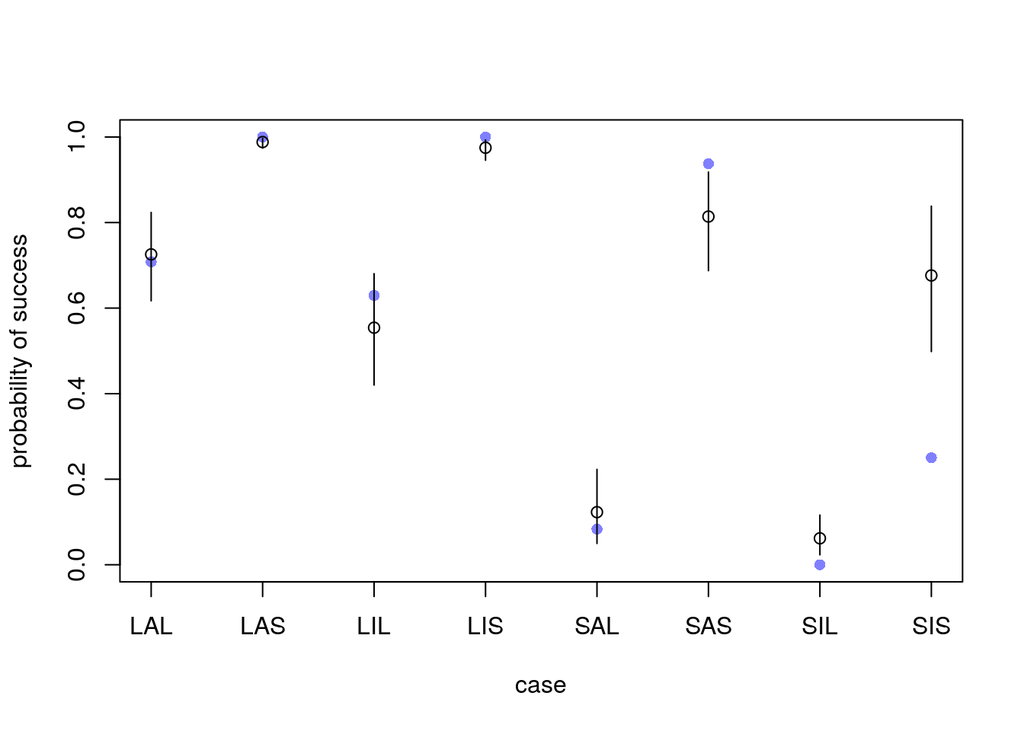

```r
set.seed(1)
p <- link(m11H3u)
p.mean <- colMeans(p)
p.PI <- apply(p, 2, PI)

d$p <- d$y / d$n
plot(d$p, col=rangi2, ylab="probability of success", xlab="case", xaxt="n",  ylim = c(0, 1), pch=16)
axis(1, at=1:8, labels=c( "LAL","LAS","LIL","LIS","SAL","SAS","SIL","SIS" ))
points( 1:8 , p.mean )
for(i in 1:8){ lines( c(i, i), p.PI[,i] ) }
```

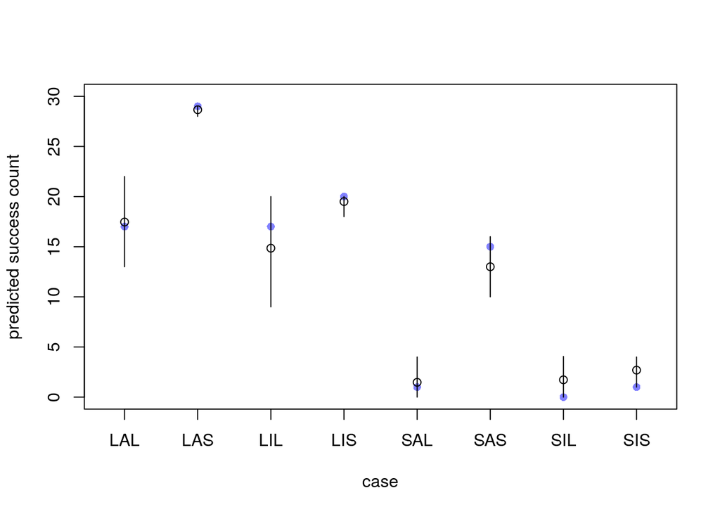

```r
set.seed(1)
y <- sim(m11H3u)
y.mean <- colMeans(y)
y.PI <- apply(y, 2, PI)

plot(d$y, col=rangi2, ylab="predicted success count", xlab="case", xaxt="n", xlim=c(0.75,8.25) , ylim = c(0, 30), pch=16)
axis(1, at=1:8, labels=c( "LAL","LAS","LIL","LIS","SAL","SAS","SIL","SIS" ))
points( 1:8 , y.mean )
for(i in 1:8){ lines(c(i, i), y.PI[,i]) }
```

Want: (c) Now try to improve the model. Consider an interaction between the pirate’s size and age (immature or adult). Compare this model to the previous one, using WAIC. Interpret.

Sol.:

```r
set.seed(1)
l11H3c <- alist(
        y ~ dbinom( n , p ),
        logit(p) <- a + bP*P + bV*V + bA*A + bPA*P*A,
        a ~ dnorm( 0 , 1.5 ),
        c(bP,bV,bA, bPA) ~ dnorm( 0 , 1.5 )
)
m11H3c <- ulam(l11H3c, data=dat_list, chains=4, log_lik = TRUE )
```

```
## Trying to compile a simple C file
```

```r
precis( m11H3c , depth=2 )
```

```
##           mean        sd       5.5%      94.5%     n_eff    Rhat4
## a   -0.4009886 1.0909938 -2.1810804  1.3909540  744.8722 1.002402
## bPA -1.8060080 0.6045774 -2.7886159 -0.8551963  681.3938 1.007070
## bA   0.9830003 0.7193379 -0.1308874  2.1584101  641.8780 1.006493
## bV   3.6203825 0.6496608  2.6520419  4.7510976 1018.8302 1.000439
## bP  -1.1746266 0.8490824 -2.5274561  0.1741596  636.5851 1.008464
```

```r
compare(m11H3u, m11H3c)
```

```
##            WAIC       SE    dWAIC      dSE    pWAIC     weight
## m11H3c 23.15004 4.854594 0.000000       NA 2.310028 0.98501455
## m11H3u 31.52119 5.880846 8.371153 5.036828 4.038845 0.01498545
```

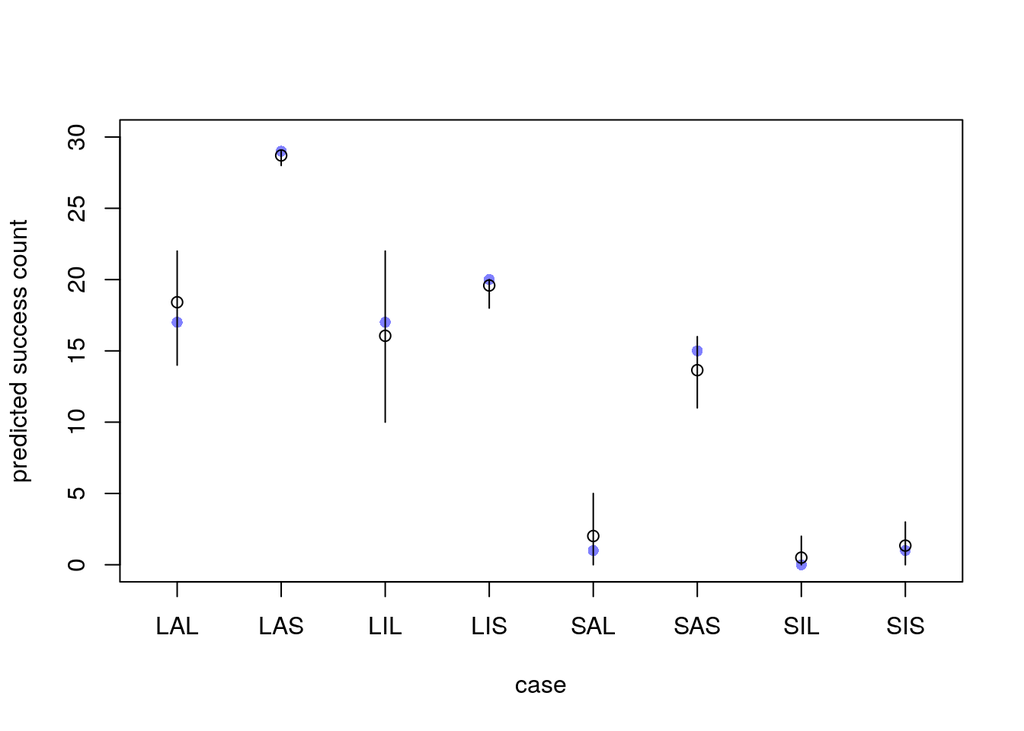

```r
set.seed(1)
y <- sim(m11H3c)
y.mean <- colMeans(y)
y.PI <- apply(y, 2, PI)

plot(d$y, col=rangi2, ylab="predicted success count", xlab="case", xaxt="n", xlim=c(0.75,8.25) , ylim = c(0, 30), pch=16)
axis(1, at=1:8, labels=c( "LAL","LAS","LIL","LIS","SAL","SAS","SIL","SIS" ))
points( 1:8 , y.mean )
for(i in 1:8){ lines(c(i, i), y.PI[,i]) }
```

- According to the WAIC the model has inproved.
- The highest successful counts are achieved by a large, adult pirate with a small victim, as expected.
- The lowest successful counts are achieved by a large victims or small and infant pirates, as expected.
- According to the precis output, the interaction effect of pirate size and adult/infant is important.

## 11H4.

Given: Salamander data.

Want: Model the relationship between density and percent cover, using a log-link. Compare ´quap´ vs ´ulam´ approximation. Plot 89 % interval.

Sol.:

```r
data("salamanders")
d <- salamanders
head(d)
```

```
##   SITE SALAMAN PCTCOVER FORESTAGE
## 1    1      13       85       316
## 2    2      11       86        88
## 3    3      11       90       548
## 4    4       9       88        64
## 5    5       8       89        43
## 6    6       7       83       368
```

```r
dat_list <- list(
    S = d$SALAMAN,
    C = standardize(d$PCTCOVER),
    A = standardize(d$FORESTAGE)
)
head(dat_list)
```

```
## $S
##  [1] 13 11 11  9  8  7  6  6  5  5  4  3  3  3  3  3  2  2  2  1  1  1  1  1  1
## [26]  1  1  1  1  0  0  0  0  0  0  0  0  0  0  0  0  0  0  0  0  0  0
##
## $C
##  [1]  0.7273231  0.7552742  0.8670786  0.8111764  0.8391275  0.6714209
##  [7]  0.6714209  0.8950297  0.8111764  0.8670786  0.7832253  0.6714209
## [13]  0.7832253  0.8391275  0.9229807  0.9509318 -1.5926175  0.7832253
## [19]  0.9509318 -1.4528621 -1.2013023 -1.1174490 -0.8379381 -0.6981826
## [25] -0.3627695  0.5875676  0.7552742  0.8111764  0.9229807 -1.6485197
## [31] -1.6205686 -1.5646665 -1.5087643 -1.4249110 -1.3969599 -1.3410577
## [37] -1.2572044 -1.1733512 -0.9776935 -0.4186717 -0.1950629  0.5037144
## [43]  0.5316655  0.5875676  0.7552742  0.8391275  0.8950297
## attr(,"scaled:center")
## [1] 58.97872
```

[output cut: 16 more lines]

```r
l11H4 <-alist(
        S ~ dpois( lambda ),
        log(lambda) <- a + bC*C,
        a ~ dnorm( 0 , 0.5 ),
        bC ~ dnorm( 0 , 0.5 )
        )
m11H4q <- quap(l11H4, data=dat_list)

precis( m11H4q , depth=2 )
```

```
##         mean        sd      5.5%     94.5%
## a  0.4798762 0.1373386 0.2603825 0.6993699
## bC 1.0567039 0.1651212 0.7928084 1.3205994
```

```r
set.seed(1)
m11H4u <- ulam(l11H4, data=dat_list, chains=4, log_lik = TRUE)
```

```
## Trying to compile a simple C file
```

```r
precis( m11H4u , depth=2 )
```

[output not shown]

```r
set.seed(1)
compare(m11H4q, m11H4u)
```

```
##            WAIC       SE    dWAIC       dSE    pWAIC    weight
## m11H4u 213.0835 26.72342 0.000000        NA 4.417122 0.5625143
## m11H4q 213.5862 26.56351 0.502745 0.4015696 4.712715 0.4374857
```

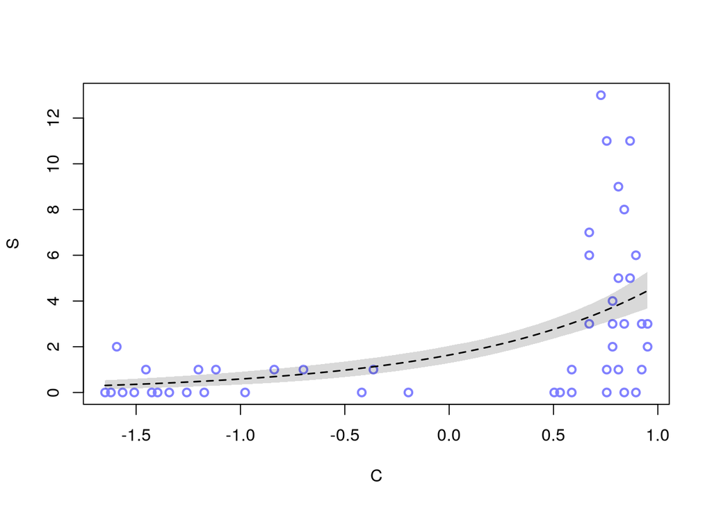

```r
set.seed(1)

plot( dat_list$C , dat_list$S , xlab="C" , ylab="S" ,
    col=rangi2 , lwd=2 ,
    ylim=c(min(dat_list$S),max(dat_list$S)),
    xlim=c(min(dat_list$C),max(dat_list$C)) )

ns <- 100
C.seq <- seq( from=min(dat_list$C) , to=max(dat_list$C) , length.out=ns )

lambda <- link( m11H4q , data=data.frame( C=C.seq) )
lmu <- apply( lambda , 2 , mean )
lci <- apply( lambda , 2 , PI )
lines( C.seq , lmu , lty=2 , lwd=1.5 )
shade( lci , C.seq , xpd=TRUE )
```

Want: Include ´FORESTAGE´ into the model. Compare. Interpret.

Sol.:

```r
l11H4c <-alist(
        S ~ dpois( lambda ),
        log(lambda) <- a + bA*A + bAC*A*C + bC*C,
        a ~ dnorm( 0 , 0.5 ),
        c(bA,bAC,bC) ~ dnorm( 0 , 0.5 )
        )
m11H4cq <- quap(l11H4c, data=dat_list)

precis( m11H4cq , depth=2 )
```

```
##            mean        sd       5.5%     94.5%
## a    0.51619991 0.1911513  0.2107033 0.8216965
## bA   0.08327017 0.2375009 -0.2963022 0.4628425
## bAC -0.07705875 0.2775582 -0.5206504 0.3665329
## bC   0.99859711 0.2365731  0.6205076 1.3766866
```

```r
set.seed(1)
m11H4cu <- ulam(l11H4c, data=dat_list, chains=4, log_lik = TRUE)
```

```
## Trying to compile a simple C file
```

```r
precis( m11H4cu , depth=2 )
```

```
##            mean        sd       5.5%     94.5%    n_eff    Rhat4
## a    0.49158538 0.2019078  0.1700975 0.8088995 497.6164 1.004482
## bC   1.02617277 0.2498578  0.6277796 1.4289854 468.5482 1.004777
## bAC -0.08356163 0.2894173 -0.5529230 0.3886716 453.1097 1.006414
## bA   0.08368314 0.2456070 -0.3313147 0.4756404 427.3431 1.007181
```

```r
set.seed(1)
compare(m11H4cq, m11H4cu)
```

```
##             WAIC       SE     dWAIC       dSE    pWAIC    weight
## m11H4cu 219.1356 27.61338 0.0000000        NA 8.424209 0.5466997
## m11H4cq 219.5103 27.37234 0.3746896 0.5743737 8.545825 0.4533003
```

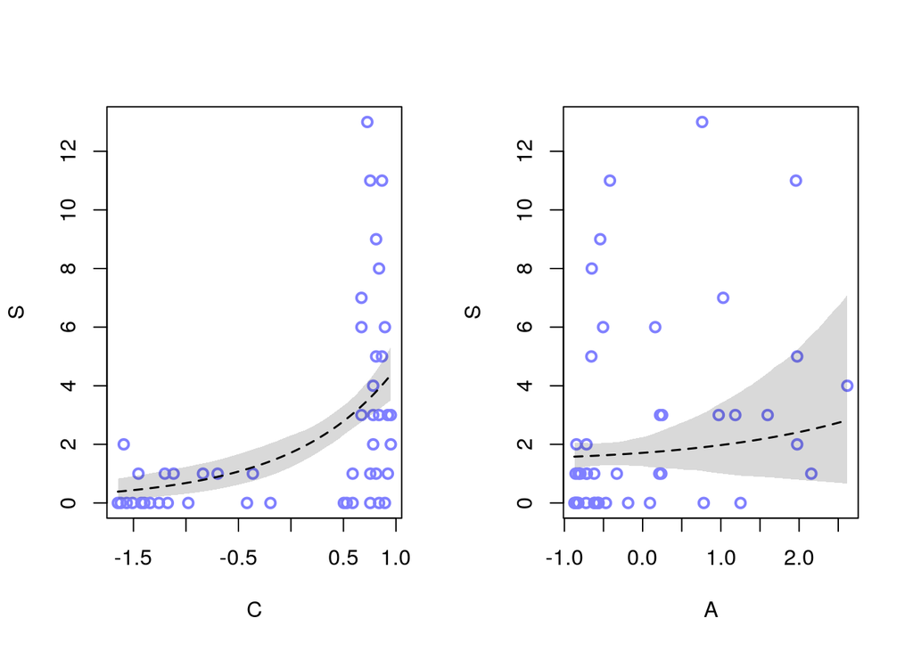

```r
set.seed(1)

par(mfrow=c(1,2))

# vary C
plot( dat_list$C , dat_list$S , xlab="C" , ylab="S" ,
    col=rangi2 , lwd=2 ,
    ylim=c(min(dat_list$S),max(dat_list$S)),
    xlim=c(min(dat_list$C),max(dat_list$C)) )

ns <- 100
C.seq <- seq( from=min(dat_list$C) , to=max(dat_list$C) , length.out=ns )

lambda <- link( m11H4cq , data=data.frame( C=C.seq, A=0) )
lmu <- apply( lambda , 2 , mean )
lci <- apply( lambda , 2 , PI )
lines( C.seq , lmu , lty=2 , lwd=1.5 )
shade( lci , C.seq , xpd=TRUE )

# vary A
plot( dat_list$A , dat_list$S , xlab="A" , ylab="S" ,
    col=rangi2 , lwd=2 ,
    ylim=c(min(dat_list$S),max(dat_list$S)),
    xlim=c(min(dat_list$A),max(dat_list$A)) )

A.seq <- seq( from=min(dat_list$A) , to=max(dat_list$A) , length.out=ns )

lambda <- link( m11H4cq , data=data.frame( A=A.seq, C=0) )
lmu <- apply( lambda , 2 , mean )
lci <- apply( lambda , 2 , PI )
lines( A.seq , lmu , lty=2 , lwd=1.5 )
shade( lci , A.seq , xpd=TRUE )
```

- According to the plots, most datapoints are not in the predicted 89 % interval.
- According to the precis output, the contribution of forestage to the prediction is very small.
- According to the model the number of salamander increases with ground cover. The age of the trees does not matter.